# Análisis Multivariado - Clase 7

2025-09-24

## Regresión multivariada

## Regresión

En estadística, un modelo de regresión busca establecer y cuantificar un vínculo entre una/s variable/s de interés (generalmente notadas con la letra \(Y\)) y otra/s variable/s que explican los valores de la variable de interés (generalmente notadas con la letra \(X\)). Es decir, existe una función \(g\) de forma que \[Y=g(X)+\varepsilon ,\] donde \(\varepsilon\) representa todo lo que no fue contemplado en el modelo y se suele asumir que tiene media 0.

## Regresión lineal simple

- **Modelo:** El modelo de regresión lineal simple asume que la función \(g\) es una función lineal y depende de una única variable. Es decir, todos los pares \((X,Y)\) se disponen en torno a alguna recta: \[Y_i=\beta_0+\beta_1\cdot X_i +\varepsilon_i ,\] donde el índice \(i\) se utiliza para individualizar cada observación de la base.
- **Estimación:** Una vez planteado el modelo, entre todas las ordenadas \(\beta_0\) y las pendientes \(\beta_1\), se eligen como valores óptimos \(\widehat{\beta} _0\) y \(\widehat{\beta} _1\) aquellos que minimicen la suma del cuadrado de las diferencias entre \(Y_i\) y \(\widehat{\beta} _0+\widehat{\beta} _1\cdot X_i\).

## Regresión Lineal Múltiple

- **Modelo:** Los modelos de regresión lineal múltiple asumen que una variable pueda depender de **más de una** variable, pero siempre respetando la estructura lineal. Es decir, \[Y_i=\beta_0+\beta_1\cdot X_{i,1}+\beta_2\cdot X_{i,2}+\cdots+\beta_p\cdot X_{i,p} +\varepsilon_i \]
- **Estimación:** Luego de plantear este modelo, se obtienen valores óptimos \(\widehat{\beta} _0,\widehat{\beta} _1,\cdots,\widehat{\beta} _p\) minimizando las diferencias entre \(Y_i\) y \(\beta_0+\beta_1\cdot X_{1,i}+\beta_2\cdot X_{2,i}+\cdots+\beta_p\cdot X_{p,i}\) sumadas.

## Regresión Lineal Multivariada

- **Modelo:** Los modelos de regresión lineal multivariada asumen que **un conjunto de variables** pueda depender en simultáneo de una o más variables, respetando la estructura lineal. Es decir,

\[ \left\lbrace \begin{array}{c} Y_{i,1}=\beta_{0,1}+\beta_{1,1}\cdot X_{i,1}+\beta_{2,1}\cdot X_{i,2}+\cdots+\beta_{p,1}\cdot X_{i,p} +\varepsilon_{i,1}\\ Y_{i,2}=\beta_{0,2}+\beta_{1,2}\cdot X_{i,1}+\beta_{2,2}\cdot X_{i,2}+\cdots+\beta_{p,2}\cdot X_{i,p} +\varepsilon_{i,2}\\ \cdots \\ Y_{i,r}=\beta_{0,r}+\beta_{1,r}\cdot X_{i,1}+\beta_{2,r}\cdot X_{i,2}+\cdots+\beta_{p,r}\cdot X_{i,r} +\varepsilon_{i,r}\\ \end{array} \right\rbrace \]

Este conjunto de ecuaciones para cada inmueble \(i\) se puede resumir matricialmente del siguiente modo:

\[\underset{1\times r}{\underbrace{\mathbf{Y_i}}} =\underset{1\times p}{\underbrace{\mathbf{X}_i}} \times \underset{p\times r}{\underbrace{\mathbf{B}}} + \underset{1\times r}{\underbrace{\mathbf{E_i}}} \]

## Representación matricial

Más aún, para las \(n\) observaciones se puede resumir del siguiente modo: \[\underset{n\times r}{\underbrace{\mathbf{Y}}} =\underset{n\times p}{\underbrace{\mathbf{X}}} \times \underset{p\times r}{\underbrace{\mathbf{B}}} + \underset{n\times r}{\underbrace{\mathbf{E}}} \]

- **Estimación:** Con el mismo criterio de mínimos cuadrados se obtiene una matriz óptima de coeficientes \(\mathbf{\widehat{B}}\).

## Análisis Factorial

## Datos Simulados

```
##   Matemática   Física Literatura Historia   Teatro Plástica
## 1   63.38228 73.84462   58.33320 66.43355 48.61096 69.42431
## 2   58.85478 65.55770   62.54841 70.37102 46.62198 66.86952
## 3   62.71233 73.11769   56.97466 67.98659 48.96397 67.44874
## 4   62.84090 72.06735   54.66779 64.91296 46.75756 66.26778
## 5   59.93670 68.83477   56.62078 66.05345 49.40234 70.87256
## 6   54.67754 62.08166   56.53119 67.78810 44.49258 64.66940
```

## Factores latentes

Uno podría imaginarse que hay alguna variable de “inteligencia general” o “rendimiento general” influyendo sobre todas estos puntajes.

De todas formas, una variable de este estilo no sería observable ni medible. Por lo tanto, podríamos querer conseguir información esta variable **latente** a partir de los datos que sí son observables (los puntajes).

## Modelo de Factor Latente

Es decir, podríamos considerar una única variable \(F\) que impacta sobre **todas** las variables, aunque puede impactar de distinta manera en distintas variables, mediante un coeficiente \(\lambda\) (llamado **carga**).

De todas formas, no alcanzaría para explicar de forma completa todas las variables, por lo que hay un término específico \(U\) que corresponde a la **unicidad** de cada variable: \[ \small \begin{array}{c} \text{M}=X_1=\lambda_1\cdot F + U_1\\ \text{F}=X_2=\lambda_2\cdot F + U_2\\ \text{L}=X_3=\lambda_3\cdot F + U_3\\ \text{H}=X_4=\lambda_4\cdot F + U_4\\ \text{T}=X_5=\lambda_5\cdot F + U_5\\ \text{P}=X_6=\lambda_6\cdot F + U_6\\ \end{array} \] Mientras más grande sea \(\lambda\) (en valor absoluto), más relación tendrá la variable correspondiente con el factor \(F\).

## Hipótesis

Asumimos que las variables y el factor están estandarizados. Es decir, \(E(X_i)=E(F)=0\) y \(V(X_i)=V(F)=1\).

Cada variable de unicidad \(U_i\) también tiene media cero (\(E(U_i)=0\)), pero pueden diferir sus varianzas (\(V(U_i)=\psi_{i}^2\)).

Además, asumimos que las variables de unicidad no están correlacionadas entre sí ni con el factor común a todas las variables. Es decir, \(\text{Cov}(U_i,U_j)=\text{Cov}(U_i,F)=0\)

## Distribución del vector

Al asumir este modelo, obtenemos que el vector aleatorio \(\mathbf{X}=(X_1,X_2,X_3,X_4,X_5,X_6)\) cumple lo siguiente:

- **Valor esperado:** \(E(\vec{X})=\vec{\mu}=\vec{0}\)
- **Matriz de covarianza:** \(\text{Cov}(\vec{X})=\mathbf{\Sigma}= \begin{pmatrix} \lambda_1^2 + \psi_1^2 & \lambda_1\cdot \lambda_2 & \cdots & \lambda_1\cdot \lambda_6\\ \lambda_2\cdot\lambda_1 & \lambda_2^2+ \psi_2^2 & \cdots & \lambda_2\cdot \lambda_6\\ \vdots & \vdots & \ddots \vdots\\ \lambda_6\cdot\lambda_1 & \lambda_6\cdot \lambda_2 & \cdots & \lambda_6^2+ \psi_1^2\\ \end{pmatrix}\)

## Representación matricial

Matricialmente podemos resumir este modelo como \[\vec{X}=\vec{\lambda}\cdot F+ \vec{U} \] donde

- \(\vec{X}=(X_1,X_2,X_3,X_4,X_5,X_6)\)
- \(\vec{\lambda}=(\lambda_1,\lambda_2,\cdots,\lambda_6)\)
- \(\vec{U}=(U_1,U_2,U_3,U_4,U_5,U_6)\)

Además, considerando una matriz diagonal \(\mathbf{\Psi}\) que contiene a cada \(\psi_i^2\) en cada coordenada \((i,i)\), podemos reescribir \(\mathbf{\Sigma}\) de este modo: \[\underset{p\times p}{\underbrace{\mathbf{\Sigma}}}=\underset{p\times 1}{\underbrace{\vec{\lambda}^T}}\times \underset{1\times p}{\underbrace{\vec{\lambda}}} + \underset{p\times p}{\underbrace{\mathbf{\Psi}}}\]

## Estimación de los parámetros

Una vez observados los datos, se obtiene una matriz de covarianza **estimada** \(\mathbf{S}\).

Los parámetros \(\lambda_i\) y \(\psi_i^2\) se estiman de dos modos.

## Principal Factor Analysis

Se considera la matriz de covarianza reducida, donde se remueve lo específico de cada variable. Es decir, \[\mathbf{S}^{\ast}=S-\widehat{\mathbf{\Psi}}=\widehat{\vec{\lambda}}^T\times \widehat{\vec{\lambda}}\]

El problema es que no se puede estimar \(\vec{\lambda}\) sin \(\widehat{\mathbf{\Psi}}\). Sin embargo, como se considera que se removió todo lo específico de cada variable, queda sólo lo relativo al factor común \(F\). Por lo tanto, se inicia un algoritmo que comienza con una estimación inicial de las covarianzas comunes:

- **Opción 1:** \(\widehat{\lambda}_i^0\) = El valor de \(R^2\) de una regresión lineal múltiple de \(X_i\) vs. las otras variables \(X_j\) (\(i\neq j\)).
- **Opción 2:** \(\widehat{\lambda}_i^0 = \max_{j\neq i} \{\rho^2(X_i,X_j)\}\).

Con esa estimación inicial de \(\vec{\lambda}\), se puede estimar \(\widehat{\mathbf{\Psi}}\) e iterar hasta converger.

## Máxima verosimilitud

Si se considera que el vector aleatorio \(\vec{X}\) sigue una **distribución normal multivariada**, se puede establecer una función de verosimilitud acorde asumiendo la estructura de covarianza dada por \(\mathbf{\Sigma}=\vec{\lambda}^T\times \vec{\lambda} + \mathbf{\Psi}\) y bajo este modelo encontrar los valores de \(\widehat{\vec{\lambda}}\) y \(\widehat{\mathbf{\Psi}}\) que maximicen dicha verosimilitud.

A lo largo de esta presentación, usaremos esta metodología.

## Resultados

```
##
## Loadings:
##            Factor1
## Matemática
## Física
## Literatura
## Historia
## Teatro     0.997
## Plástica   0.957
##
##                Factor1
## SS loadings      1.913
## Proportion Var   0.319
```

Unicidad:

```
## Matemática     Física Literatura   Historia     Teatro   Plástica
## 0.99997093 0.99983813 0.99957414 0.99824449 0.00500000 0.08405881
```

## Comentarios

Notar que el factor encuentra correlación muy fuerte con los puntajes de Plástica y Teatro. Por lo tanto, podríamos decir que el algoritmo encontró como factor común una “inteligencia creativa y/o artística”.

Pero hay otros resultados que muestran que ese factor no está representando a todas las variables por igual, la unicidad de las variables restantes es muy alta (cercanas al valor máximo de 1).

## Múltiples factores

Supongamos que consideramos \(k\) factores \(F_1,F_2,\cdots ,F_k\), en vez de un **único** factor que represente a la correlación entre **todas** las variables: \[\begin{array}{c} X_1=\lambda_{1,1}\cdot F_1+\cdots+ \lambda_{1,k}\cdot F_k + U_1\\ X_2=\lambda_{2,1}\cdot F_1 +\cdots+ \lambda_{2,k}\cdot F_k+ U_2\\ X_3=\lambda_{3,1}\cdot F_1 +\cdots+ \lambda_{3,k}\cdot F_k+ U_3\\ X_4=\lambda_{4,1}\cdot F_1+\cdots+ \lambda_{4,k}\cdot F_k + U_4\\ X_5=\lambda_{5,1}\cdot F_1 +\cdots+ \lambda_{5,k}\cdot F_k+ U_5\\ X_6=\lambda_{6,1}\cdot F_1 +\cdots+ \lambda_{6,k}\cdot F_k + U_6\\ \end{array} \]

## Representación matricial

Matricialmente: \[\underset{p\times 1}{\underbrace{\vec{X}}}=\underset{p\times k}{\underbrace{\mathbf{\Lambda}}}\times \underset{k\times 1}{\underbrace{\vec{F}}}+ \underset{p\times 1}{\underbrace{\vec{U}}}\]

Además, la matriz de covarianza de \(\vec{X}\) se obtiene también reemplazando \(\vec{\lambda}\) por la matriz \(\mathbf{\Lambda}\)

\[\underset{p\times p}{\underbrace{\mathbf{\Sigma}}}=\underset{p\times k}{\underbrace{\mathbf{\Lambda}}}\times \underset{k\times p}{\underbrace{\mathbf{\Lambda}^T}} + \underset{p\times p}{\underbrace{\mathbf{\Psi}}}\] La estimación por máxima verosimilitud también es análoga reemplazando esta expresión para la matriz de covarianza.

## Resultados (2 factores)

```
##
## Loadings:
##            Factor1 Factor2
## Matemática  0.337   0.939
## Física      0.321   0.883
## Literatura
## Historia
## Teatro      0.941  -0.331
## Plástica    0.907  -0.305
##
##                Factor1 Factor2
## SS loadings      1.926   1.866
## Proportion Var   0.321   0.311
## Cumulative Var   0.321   0.632
```

Unicidad:

```
## Matemática     Física Literatura   Historia     Teatro   Plástica
## 0.00500000 0.11817602 0.99905251 0.99738680 0.00500000 0.08387715
```

## Resultados (3 factores)

```
##
## Loadings:
##            Factor1 Factor2 Factor3
## Matemática  0.609  -0.594   0.521
## Física      0.573  -0.560   0.490
## Literatura -0.159   0.575   0.799
## Historia   -0.116   0.497   0.648
## Teatro      0.746   0.556  -0.225
## Plástica    0.788   0.562  -0.242
##
##                Factor1 Factor2 Factor3
## SS loadings      1.914   1.870   1.680
## Proportion Var   0.319   0.312   0.280
## Cumulative Var   0.319   0.631   0.911
```

Unicidad:

```
## Matemática     Física Literatura   Historia     Teatro   Plástica
## 0.00500000 0.11819105 0.00500000 0.31957102 0.08359902 0.00500000
```

## Proyección sobre factores

Vemos que las variables no se alinean completamente con los factores, aunque se ubican cerca variables que deberían ser similares

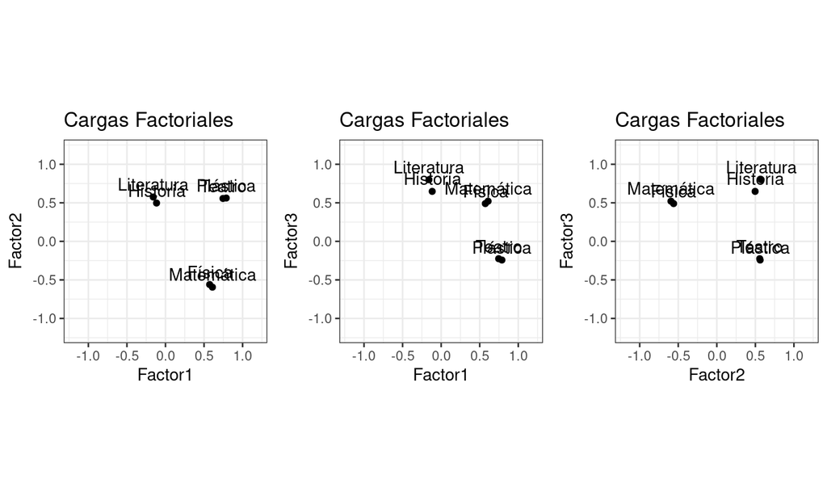

## Rotaciones

Se puede demostrar que la solución del análisis factorial no es única. Es decir, se puede obtener con otro conjunto de factores la misma matriz de covarianza y por ende, la misma función de verosimilitud.

Por ejemplo, si se toma una matriz de rotación \(P\) (es decir, cumple \(P^T\times P=I\)), obtenemos el mismo modelo con \(\widetilde{\mathbf{\Lambda}}=\mathbf{\Lambda} \times P\) y \(\widetilde{\vec{F}}=P^T \times \vec{F}\): \[\vec{X}=\widetilde{\mathbf{\Lambda}}\times \widetilde{\vec{F}}+ \vec{U}=\mathbf{\Lambda} \times \underset{I}{\underbrace{P\times P^T}} \times \vec{F} + \vec{U}=\mathbf{\Lambda} \times \vec{F} + \vec{U}\]

Esto pareciera complicar las cosas, pero en general esta propiedad se utiliza para poder interpretar mejor los factores. Una de las rotaciones se llama “varimax” e intenta que las variables se vean más alineadas con los factores.

## Resultados varimax

```
##
## Loadings:
##            Factor1 Factor2 Factor3
## Matemática          0.997
## Física              0.939
## Literatura                  0.997
## Historia                    0.824
## Teatro      0.957
## Plástica    0.997
##
##                Factor1 Factor2 Factor3
## SS loadings      1.911   1.877   1.675
## Proportion Var   0.319   0.313   0.279
## Cumulative Var   0.319   0.631   0.911
```

Unicidad:

```
## Matemática     Física Literatura   Historia     Teatro   Plástica
## 0.00500000 0.11819105 0.00500000 0.31957102 0.08359902 0.00500000
```

## Proyección Rotada

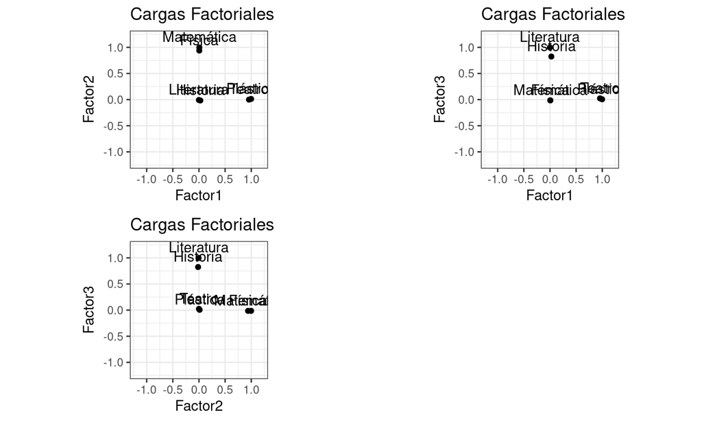

**Conclusión** Con estos factores, se podría considerar que el Factor 1 representa la “inteligencia artística”, el Factor 2 representa la “inteligencia lógico/matemática” y el Factor 3 la “inteligencia social”.

## Matriz de correlación

Era esperable que 3 factores fueran tan representativos viendo la matriz de correlación:

```
##              Matemática       Física  Literatura    Historia      Teatro
## Matemática  1.000000000  0.936698016 -0.02199886 -0.02826924 0.005808116
## Física      0.936698016  1.000000000 -0.02131279 -0.02970950 0.009954012
## Literatura -0.021998860 -0.021312791  1.00000000  0.82230670 0.021863377
## Historia   -0.028269244 -0.029709500  0.82230670  1.00000000 0.042552344
## Teatro      0.005808116  0.009954012  0.02186338  0.04255234 1.000000000
## Plástica    0.019321883  0.017584550  0.00451700  0.03080816 0.954655563
##              Plástica
## Matemática 0.01932188
## Física     0.01758455
## Literatura 0.00451700
## Historia   0.03080816
## Teatro     0.95465556
## Plástica   1.00000000
```

## Selección de \(k\)

- No se puede elegir cualquier valor de \(k<p\) ya que la cantidad de parámetros es \(\dfrac{(p-k)^2-(p+k)}{2}\).
- Una forma de elegir la cantidad de factores es según la varianza explicada. De todas formas, al no ser el objetivo del análisis factorial, se suele ser más tolerante con el porcentaje requerido.
- Otra forma es mirando los autovalores de la matriz de correlación de los datos. Autovalores mayores que 1 representan direcciones que pueden explicar más de una variable (la correlación de una variable es 1), por lo que puede considerarse que hay un factor que pueda resumir esa información común a más de una variable. En este caso también se justifica elegir 3 factores:

```
## [1] 1.97551374 1.95390430 1.78476113 0.17742121 0.06374743 0.04465219
```

## Scores

Una vez obtenidos los factores y estimados los parámetros, podríamos mirar cómo representar cada dato en términos de dichos factores. Para eso, hay que poder estimar el valor de cada factor para un conjunto de datos \(\mathbf{x}\).

Utilizando la distribución multivariada asumida, se considera la siguiente estimación para el vector de factores: \[\widehat{\vec{F}}=\widehat{\mathbf{\Lambda}}^T \times \mathbf{S}^{-1}\times \mathbf{x}\]

## Representación de scores

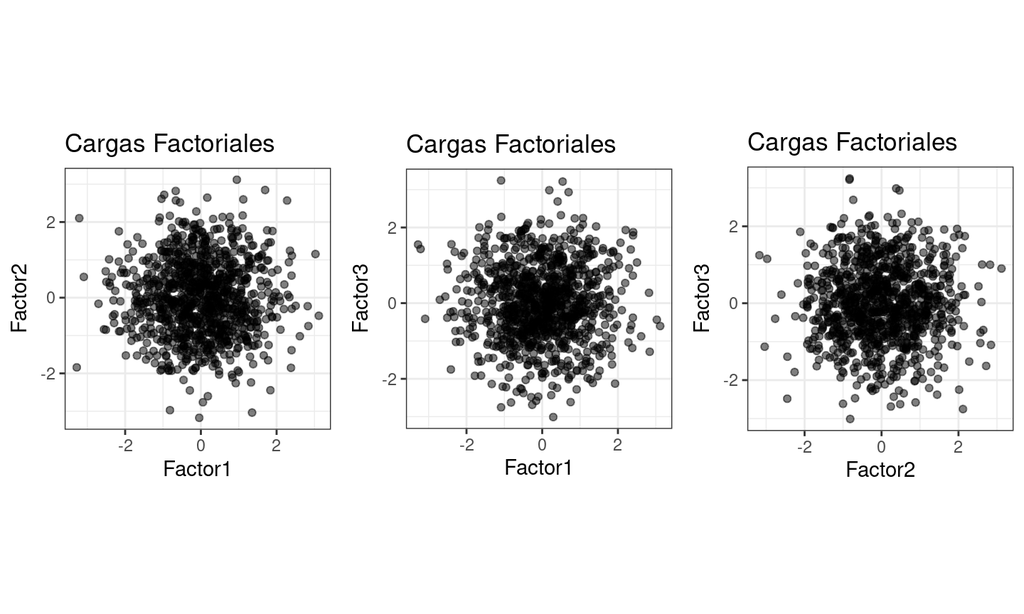

## Representación de scores

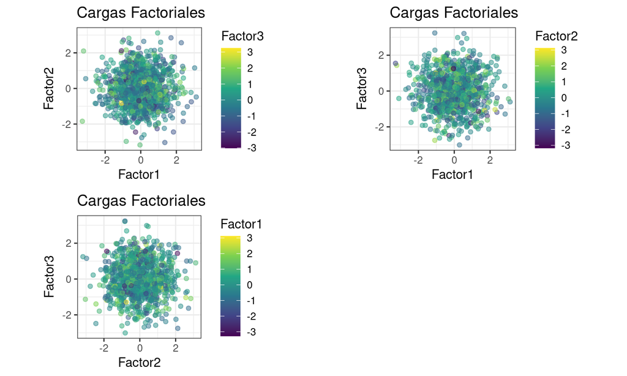

## Datos ortogonales

```
##   Matemática Literatura   Teatro
## 1   63.38228   58.33320 48.61096
## 2   58.85478   62.54841 46.62198
## 3   62.71233   56.97466 48.96397
## 4   62.84090   54.66779 46.75756
## 5   59.93670   56.62078 49.40234
## 6   54.67754   56.53119 44.49258
```

## Correlación y autovalores

```
##              Matemática  Literatura      Teatro
## Matemática  1.000000000 -0.02199886 0.005808116
## Literatura -0.021998860  1.00000000 0.021863377
## Teatro      0.005808116  0.02186338 1.000000000
```

```
## [1] 1.0282471 1.0058080 0.9659449
```

## Resultados

```
##
## Call:
## factanal(x = Puntajes_1[, c(1, 3, 7)], factors = 1)
##
## Uniquenesses:
## Matemática Literatura     Teatro
##      1.000      0.005      1.000
##
## Loadings:
##            Factor1
## Matemática
## Literatura  0.997
## Teatro
##
##                Factor1
## SS loadings      0.996
## Proportion Var   0.332
##
## The degrees of freedom for the model is 0 and the fit was 0
```

## Más variables

```
##   Matemática   Física Literatura Historia Economía   Inglés   Teatro Plástica
## 1   63.38228 73.84462   58.33320 66.43355 45.76027 45.28697 48.61096 69.42431
## 2   58.85478 65.55770   62.54841 70.37102 44.28528 46.97143 46.62198 66.86952
## 3   62.71233 73.11769   56.97466 67.98659 46.23434 43.20020 48.96397 67.44874
## 4   62.84090 72.06735   54.66779 64.91296 44.14653 44.33467 46.75756 66.26778
## 5   59.93670 68.83477   56.62078 66.05345 43.76773 43.27517 49.40234 70.87256
## 6   54.67754 62.08166   56.53119 67.78810 40.73682 43.65775 44.49258 64.66940
```

## Correlación

```
##              Matemática       Física  Literatura    Historia   Economía
## Matemática  1.000000000  0.936698016 -0.02199886 -0.02826924 0.71078820
## Física      0.936698016  1.000000000 -0.02131279 -0.02970950 0.72345455
## Literatura -0.021998860 -0.021312791  1.00000000  0.82230670 0.33711333
## Historia   -0.028269244 -0.029709500  0.82230670  1.00000000 0.33730566
## Economía    0.710788198  0.723454555  0.33711333  0.33730566 1.00000000
## Inglés      0.622705451  0.628292740  0.45321836  0.44790426 0.68126648
## Teatro      0.005808116  0.009954012  0.02186338  0.04255234 0.03062718
## Plástica    0.019321883  0.017584550  0.00451700  0.03080816 0.03981639
##                 Inglés       Teatro    Plástica
## Matemática  0.62270545  0.005808116  0.01932188
## Física      0.62829274  0.009954012  0.01758455
## Literatura  0.45321836  0.021863377  0.00451700
## Historia    0.44790426  0.042552344  0.03080816
## Economía    0.68126648  0.030627176  0.03981639
## Inglés      1.00000000 -0.011379778 -0.01534875
## Teatro     -0.01137978  1.000000000  0.95465556
## Plástica   -0.01534875  0.954655563  1.00000000
```

## Autovalores

Según la regla de los autovalores, también convendría considerar 3 factores:

```
## [1] 3.33552314 1.96705463 1.89644661 0.30519939 0.21071385 0.17715986 0.06340909
## [8] 0.04449345
```

## Resultados

```
Loadings:
           Factor1 Factor2 Factor3
Matemática  0.956
Física      0.970
Literatura          0.902
Historia            0.907
Economía    0.776   0.318
Inglés      0.694   0.450
Teatro                      0.957
Plástica                    0.997

               Factor1 Factor2 Factor3
SS loadings      2.948   1.958   1.913
Proportion Var   0.369   0.245   0.239
Cumulative Var   0.369   0.613   0.852
```

Unicidad:

```
## Matemática     Física Literatura   Historia   Economía     Inglés     Teatro
## 0.07619301 0.05025212 0.18238678 0.17219295 0.29547237 0.31536792 0.08371050
##   Plástica
## 0.00500000
```

## Proyección de variables

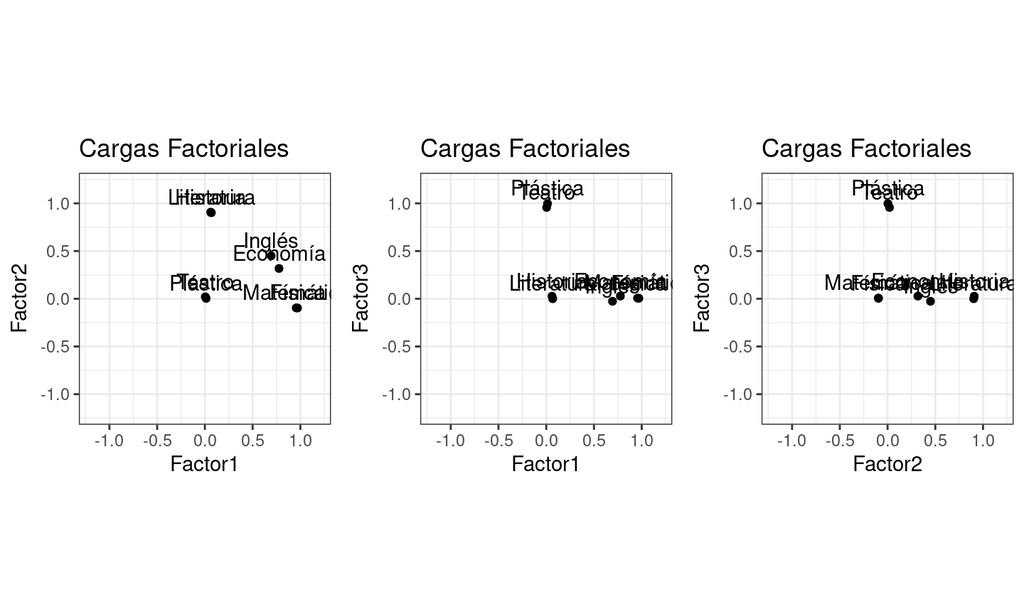

## Representación de scores

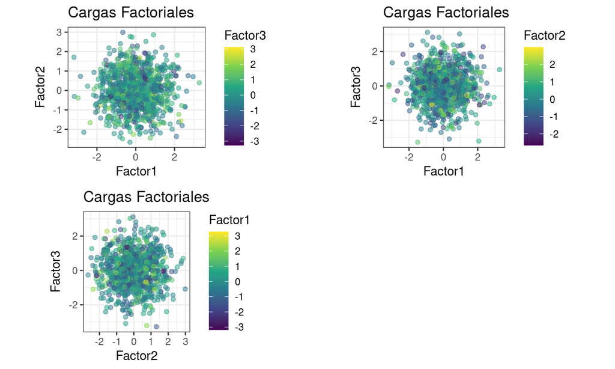

## Datos Simulados

```
##   Hidratación Alimentación Pantallas     Sueño      Test  Puntaje
## 1    94.69166    102.19951  91.10375  98.77666 Cognitivo 214.7968
## 2    97.82053    102.75819 105.44395 117.37921    Físico 185.7470
## 3   101.56877    100.60776 106.35822 106.98909    Físico 203.7226
## 4   101.93731    104.98654  90.82423  93.58370    Físico 191.1300
## 5    95.64230     97.20868  85.99073 104.62088    Físico 194.1506
## 6    97.10112    101.68953 111.76633 116.04422    Físico 186.0663
```

## Correlación y autovalores

```
##              Hidratación  Alimentación   Pantallas         Sueño    Puntaje
## Hidratación   1.00000000 -0.0416791299  0.03903744  0.0380211908  0.3293456
## Alimentación -0.04167913  1.0000000000  0.04359331 -0.0003633313 -0.3683294
## Pantallas     0.03903744  0.0435933072  1.00000000  0.0502146399 -0.3304148
## Sueño         0.03802119 -0.0003633313  0.05021464  1.0000000000  0.4251282
## Puntaje       0.32934561 -0.3683293693 -0.33041482  0.4251282219  1.0000000
```

```
## [1] 1.7408102 1.0814330 0.9784273 0.9236325 0.2756969
```

## Resultados (1 Factor)

```
##
## Loadings:
##              Factor1
## Hidratación   0.329
## Alimentación -0.369
## Pantallas    -0.330
## Sueño         0.425
## Puntaje       0.998
##
##                Factor1
## SS loadings      1.529
## Proportion Var   0.306
```

Unicidad:

```
##  Hidratación Alimentación    Pantallas        Sueño      Puntaje
##    0.8914573    0.8641703    0.8908998    0.8191084    0.0050000
```

## Resultados (2 Factores)

```
##
## Loadings:
##              Factor1 Factor2
## Hidratación   0.347
## Alimentación -0.408
## Pantallas    -0.388
## Sueño                 0.997
## Puntaje       0.909   0.410
##
##                Factor1 Factor2
## SS loadings      1.264   1.167
## Proportion Var   0.253   0.233
## Cumulative Var   0.253   0.486
```

Unicidad:

```
##  Hidratación Alimentación    Pantallas        Sueño      Puntaje
##    0.8786538    0.8338945    0.8459574    0.0050000    0.0050000
```

## Proyección de factores

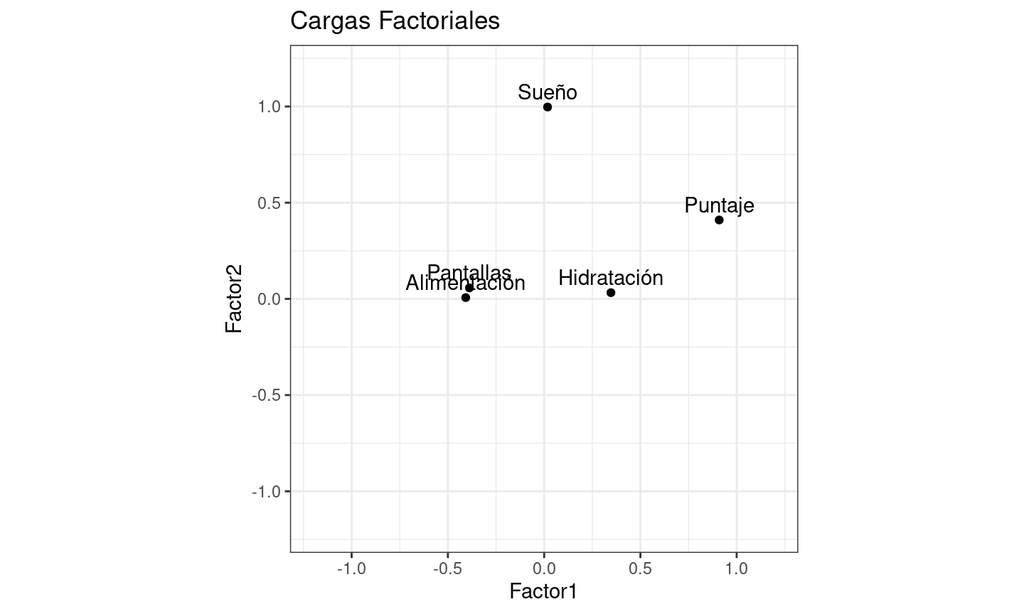

## Correlación y autovalores (1 Factor - Test Físico)

```
##              Hidratación Alimentación    Pantallas       Sueño      Puntaje
## Hidratación   1.00000000  -0.02884732 -0.010484644 -0.01735248  0.698124368
## Alimentación -0.02884732   1.00000000 -0.016420623 -0.04504663 -0.735115259
## Pantallas    -0.01048464  -0.01642062  1.000000000  0.03656435  0.002634808
## Sueño        -0.01735248  -0.04504663  0.036564348  1.00000000  0.022231689
## Puntaje       0.69812437  -0.73511526  0.002634808  0.02223169  1.000000000
```

```
## [1] 2.0292315452 1.0589577250 0.9728258225 0.9384785847 0.0005063226
```

## Resultados (1 Factor - Test Físico)

```
##
## Loadings:
##              Factor1
## Hidratación   0.696
## Alimentación -0.734
## Pantallas
## Sueño
## Puntaje       0.998
##
##                Factor1
## SS loadings      2.018
## Proportion Var   0.404
```

Unicidad:

```
##  Hidratación Alimentación    Pantallas        Sueño      Puntaje
##    0.5155740    0.4617186    0.9999922    0.9995061    0.0050000
```

## Resultados (2 Factores - Test Físico)

```
##
## Loadings:
##              Factor1 Factor2
## Hidratación   0.937   0.343
## Alimentación -0.371   0.927
## Pantallas
## Sueño
## Puntaje       0.901  -0.431
##
##                Factor1 Factor2
## SS loadings      1.828   1.164
## Proportion Var   0.366   0.233
## Cumulative Var   0.366   0.598
```

Unicidad:

```
##  Hidratación Alimentación    Pantallas        Sueño      Puntaje
##    0.0050000    0.0050000    0.9996162    0.9975748    0.0050000
```

## Proyección de factores (Test Físico)

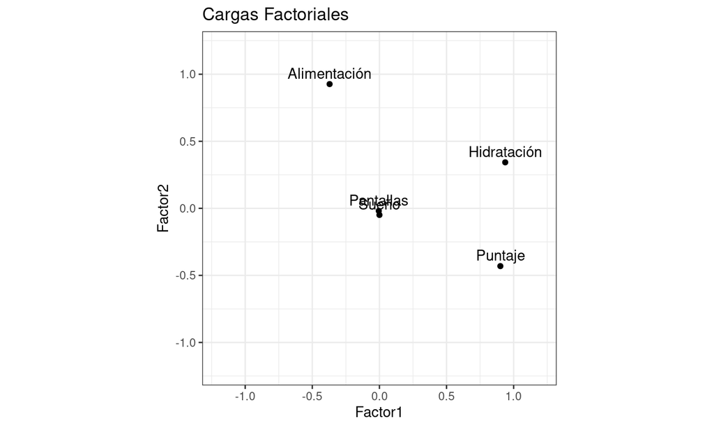

## Correlación y autovalores (1 Factor - Test Cognitivo)

```
##               Hidratación Alimentación   Pantallas      Sueño      Puntaje
## Hidratación   1.000000000  -0.05368605  0.08642466 0.08316055  0.005920917
## Alimentación -0.053686054   1.00000000  0.10374823 0.03758519 -0.041093194
## Pantallas     0.086424665   0.10374823  1.00000000 0.06126047 -0.633219797
## Sueño         0.083160550   0.03758519  0.06126047 1.00000000  0.733064345
## Puntaje       0.005920917  -0.04109319 -0.63321980 0.73306435  1.000000000
```

```
## [1] 1.9424459356 1.1717551405 1.0504792734 0.8348221310 0.0004975195
```

## Resultados (1 Factor - Test Cognitivo)

```
##
## Loadings:
##              Factor1
## Hidratación
## Alimentación
## Pantallas    -0.631
## Sueño         0.732
## Puntaje       0.998
##
##                Factor1
## SS loadings      1.931
## Proportion Var   0.386
```

Unicidad:

```
##  Hidratación Alimentación    Pantallas        Sueño      Puntaje
##    0.9999629    0.9983136    0.6022655    0.4639942    0.0050000
```

## Resultados (2 Factores - Test Cognitivo)

```
##
## Loadings:
##              Factor1 Factor2
## Hidratación           0.106
## Alimentación          0.108
## Pantallas    -0.291   0.955
## Sueño         0.935   0.348
## Puntaje       0.923  -0.380
##
##                Factor1 Factor2
## SS loadings      1.815   1.200
## Proportion Var   0.363   0.240
## Cumulative Var   0.363   0.603
```

Unicidad:

```
##  Hidratación Alimentación    Pantallas        Sueño      Puntaje
##    0.9863864    0.9882308    0.0050000    0.0050000    0.0050000
```

## Proyección de factores (Test Cognitivo)

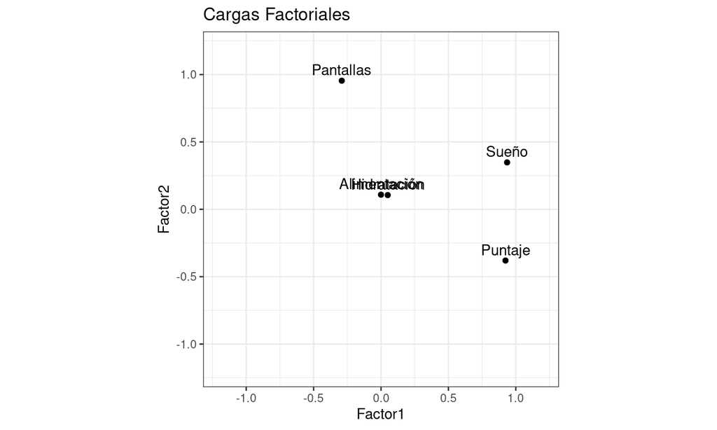